# Portfolio Modeling

We have designed 3 portfolios keeping in mind the traits of three different type of investors i.e. an agressive investor, a moderate investor, and a conservative investor.  
1. **Agressive Investor**: An agressive investor is a young investor in the age bracket of 18-35, looking for a long term investment of 30 plus years. Such an investor has high tolerance for risk and hence wants a high return.  
2. **Moderate Investor**: A moderate investor is in the age bracket of 35-50. He/she is looking for a mid-term investment horizon and have some risk taking tolerance (not much though). They are looking for moderare returns.  
3. **Safe Investor**: A safe investor is often over the age of 50, nearing retirement. He/she is typically not a risk taker and want their investments to be safe and less volatile. He/she is looking for small but steady returns.

### Portfolio for Aggressive Investor

For an agressive investor, we will invest 85% of the wealth in stocks and remaining 15% in bonds. The distribution will be as follows:  
- Large-Cap Stocks (20%): VTI  
- Mid-Cap Stocks (20%): IVOG  
- Small-Cap Stocks (20%): VB  
- International Stocks (15%): SCZ  
- Emerging Markets Stocks (10%): VWO  
- Intermediate Bonds (15%): BND

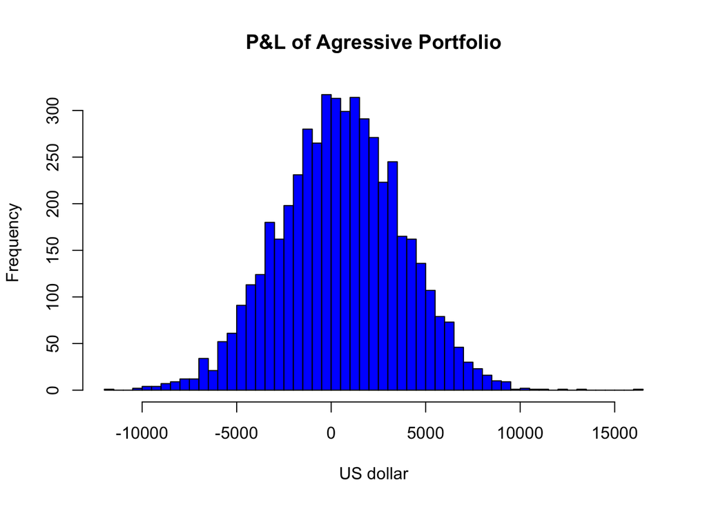

The Value at Risk of the aggressive portfolio at 5% after running Monte Carlo Simulations is negative USD 4977.34. This means that there is a probablity of 0.05 that the portfolio will fall by USD 4977.34. This can also be interpretted as a loss of USD 4977.34 will be incurred on 1 out of 20 days.

### Portfolio for Moderate Investor

For a moderate investor, we will invest 70% of the wealth in stocks and remaining 30% in bonds. The distribution will be as follows:  
- Large-Cap Stocks (20%): VTI  
- Mid-Cap Stocks (20%): IVOG  
- Small-Cap Stocks (10%): VB  
- International Stocks (15%): SCZ  
- Emerging Markets Stocks (5%): VWO  
- Intermediate Bonds (30%): BND

[figure not shown]

The Value at Risk of the moderate portfolio at 5% after running Monte Carlo Simulations is negative USD 3687.38. This means that there is a probablity of 0.05 that the portfolio will fall by USD 3687.38. This can also be interpretted as a loss of USD 3687.38 will be incurred on 1 out of 20 days. As expected, it is lower than that of the aggressive portfolio.

### Portfolio for Safe Investor

[figure not shown]

The Value at Risk of the safe portfolio at 5% after running Monte Carlo Simulations is negative USD 2634.098. This means that there is a probablity of 0.05 that the portfolio will fall by USD 2634.098. This can also be interpretted as a loss of USD 2634.098 will be incurred on 1 out of 20 days. As expected, it is the lowest when compared with the aggressive and moderate portfolios.